# MUSA650_Spring2022_HW4

## Author: Anran Zheng

## EuroSAT Land Use and Land Cover Classification using Deep Learning

In this project I implemented deep learning models to solve a typical problem in satellite imaging using a benchmark dataset. The homework was designed to make you work on increasingly more complex models.

### S1:

- Visit the EuroSAT data description page and download the data: https://github.com/phelber/eurosat
- Split the data into training (50%) and testing sets (50%), stratified on class labels (equal percentage of each class type in train and test sets).
- Convert each RGB image to grayscale and flatten the images into a data matrix (n x p: n = #samples, p = #pixels in each image)

```python
import tifffile
import numpy as np
import pandas as pd
import matplotlib.pyplot as plt
from sklearn.model_selection import train_test_split
import os
import shutil
import random
from tqdm import tqdm
import glob
import PIL
from PIL import Image
from matplotlib.pyplot import imread, imshow, subplots, show
import matplotlib.image as mpimg
import cv2
from keras.layers import Input, Dense, Activation
from keras.models import Model
from keras.utils.vis_utils import plot_model
from keras.models import Sequential
from keras.layers import Dense, Dropout, Flatten, Conv2D, MaxPooling2D, Input, GlobalAveragePooling2D
import keras
from tensorflow.keras.optimizers import RMSprop, Adam, SGD, Adadelta
from keras import utils as np_utils
from sklearn.metrics import accuracy_score, confusion_matrix, roc_auc_score
```

```python
files=[]
filedir=r"EuroSAT/2750"
for file in glob.glob(filedir + os.sep + "*" + os.sep + "*.jpg"):
  files.append(file)
```

```
EuroSAT/2750\AnnualCrop\AnnualCrop_1.jpg
```

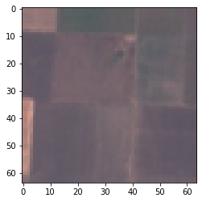

```python
print(files[0])
plt.imshow(plt.imread(files[0]))
```

```python
image = PIL.Image.open(files[0])
image_size = image.size
print(image_size)
```

```
(64, 64)
```

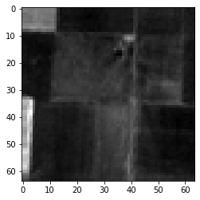

```python
#test: convert one single RGB picture to grey and then flatten
def rgb2gray(rgb):
    return np.dot(rgb[...,:3], [0.299, 0.587, 0.144])

img = mpimg.imread(files[0])

gray = rgb2gray(img)

plt.imshow(gray, cmap = plt.get_cmap('gray'))
plt.show()
```

```python
gray_img=gray.reshape(1, 4096).squeeze().flatten()
gray_img
```

```
array([132.858, 132.26 , 131.23 , ..., 102.291, 102.291, 102.878])
```

```python
example = 'EuroSAT/2750\AnnualCrop\AnnualCrop_1.jpg'
temp = example.split('\\')
#label
temp[1]
```

```
'AnnualCrop'
```

```python
#apply to the whole dataset
eurosat=[]
eurosat_label=[]
for img in files:
  img_arr = imread(img)
  gray_img = rgb2gray(img_arr).reshape(1, 4096).squeeze().flatten()
  eurosat.append(gray_img)
  label = img.split('\\')[1]
  eurosat_label.append(label)
```

```python
#change list of arrays into matrix
eurosat1=np.vstack(eurosat)
eurosat1.shape
```

```
(27000, 4096)
```

```python
eurosat_label1=np.vstack(eurosat_label).reshape(27000,)
eurosat_label1
```

```
array(['AnnualCrop', 'AnnualCrop', 'AnnualCrop', ..., 'SeaLake',
       'SeaLake', 'SeaLake'], dtype='<U20')
```

```python
label_list = eurosat_label1.tolist()

#replace categorical name with labels in eurosat_label1
for i in range(len(label_list)):
    if label_list[i] == 'AnnualCrop':
        label_list[i] = 0
    elif label_list[i] == 'Forest':
        label_list[i] = 1
    elif label_list[i] == 'HerbaceousVegetation':
        label_list[i] = 2
    elif label_list[i] == 'Highway':
        label_list[i] = 3
    elif label_list[i] == 'Industrial':
        label_list[i] = 4
    elif label_list[i] == 'Pasture':
        label_list[i] = 5
    elif label_list[i] == 'PermanentCrop':
        label_list[i] = 6
    elif label_list[i] == 'Residential':
        label_list[i] = 7
    elif label_list[i] == 'River':
        label_list[i] = 8
    elif label_list[i] == 'SeaLake':
        label_list[i] = 9
```

```python
eurosat_label2=np.vstack(label_list).reshape(27000,)
eurosat_label2
```

```
array([0, 0, 0, ..., 9, 9, 9])
```

```python
#Split the data into training (50%) and testing sets (50%)
#stratified on class labels (equal percentage of each class type in train and test sets)
X_train, X_test, y_train, y_test = train_test_split(eurosat1, eurosat_label2, stratify = eurosat_label2, train_size = 0.5, random_state= 10)
```

```python
X_train.shape
```

```
(13500, 4096)
```

```python
y_train.shape
```

```
(13500,)
```

### S2:

- Implement a first deep learning model (M.1) using a fully connected network with a single fully connected layer (i.e: input layer + fully connected layer as the output layer).

Q2.1: Calculate classification accuracy on the test data.

17.414814233779907%

```python
batch_size = 1100
num_classes = 10
epochs = 10
```

```python
def train_model(model, train, test, num_classes):
    x_train = train[0].reshape((train[0].shape[0],) + input_shape)
    x_test = test[0].reshape((test[0].shape[0],) + input_shape)
    x_train = x_train.astype('float32')
    x_test = x_test.astype('float32')
    x_train /= 255
    x_test /= 255
    print('x_train shape:', x_train.shape)
    print(x_train.shape[0], 'train samples')
    print(x_test.shape[0], 'test samples')

    # convert class vectors to binary class matrices
    y_train = keras.utils.np_utils.to_categorical(train[1], num_classes)
    y_test = keras.utils.np_utils.to_categorical(test[1], num_classes)

    model.compile(loss='categorical_crossentropy',
                  optimizer=Adam(),
                  metrics=['accuracy'])

    model.fit(x_train, y_train,
              batch_size=batch_size,
              epochs=epochs,
              verbose=1,
              validation_data=(x_test, y_test))
    score = model.evaluate(x_test, y_test, verbose=0)
    print('Test score:', score[0])
    print('Test accuracy:', score[1])
```

```python
# Implement a first deep learning model (M.1)
#a fully connected network with a single fully connected layer (i.e: input layer + fully connected layer as the output layer).
input_shape=(4096,)
model = Sequential()
model.add(Dense(num_classes, activation='softmax'))
```

```python
train_model(model,
            (X_train, y_train),
            (X_test, y_test), num_classes)
```

```
x_train shape: (13500, 4096)
13500 train samples
13500 test samples
Test score: 2.1994082927703857
Test accuracy: 0.17414814233779907
```

```python
model.summary()
```

```
Model: "sequential"
_________________________________________________________________
 Layer (type)                Output Shape              Param #
=================================================================
 dense (Dense)               (None, 10)                40970

=================================================================
Total params: 40,970
Trainable params: 40,970
Non-trainable params: 0
_________________________________________________________________
```

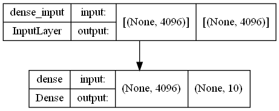

```python
import pydotplus
import pydot_ng as pydot
import graphviz
from keras.utils.vis_utils import plot_model
from keras.utils.vis_utils import pydot
#keras.utils.vis_utils.pydot = pydotplus

pydot.find_graphviz()
plot_model(model, show_shapes=True, show_layer_names=True)
```

### S3:

- Implement a second deep learning model (M.2) adding an additional fully connected hidden layer (with an arbitrary number of nodes) to the previous model.

Q3.1: Calculate classification accuracy on the test data.

15.874074399471283%

```python
model2 = Sequential()
model2.add(Dense(900, activation='relu', input_shape=(4096,)))
model2.add(Dense(num_classes, activation='softmax'))

model2.summary()
```

```
Model: "sequential_1"
_________________________________________________________________
 Layer (type)                Output Shape              Param #
=================================================================
 dense_1 (Dense)             (None, 900)               3687300

 dense_2 (Dense)             (None, 10)                9010

=================================================================
Total params: 3,696,310
Trainable params: 3,696,310
Non-trainable params: 0
_________________________________________________________________
```

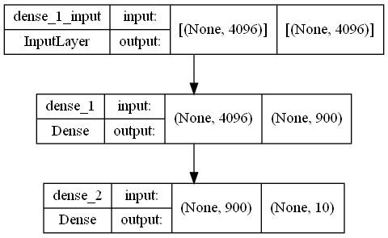

```python
plot_model(model2, show_shapes=True, show_layer_names=True)
```

```python
train_model(model2,
            (X_train, y_train),
            (X_test, y_test), num_classes)
```

```
x_train shape: (13500, 4096)
13500 train samples
13500 test samples
Test score: 2.187528133392334
Test accuracy: 0.15874074399471283
```

### S4:

- Implement a third deep learning model (M.3) adding two additional fully connected hidden layers (with arbitrary number of nodes) for a total of four, as well as drop-out layers to the previous model.

Q4.1: Calculate classification accuracy on the test data.

Answer: 28.422221541404724%

Q4.2: Compare against previous models. Which model was the "best"? Why?

Model3 preforms the best since it contains more layers of neurons and drop outs, which can make the model more robust and less over-fitting.

```python
model3 = Sequential()
model3.add(Dense(2700, activation='relu', input_shape=(4096,)))
model3.add(Dropout(0.2))
model3.add(Dense(1800, activation='relu'))
model3.add(Dropout(0.2))
model3.add(Dense(900, activation='relu'))
model3.add(Dropout(0.2))
model3.add(Dense(num_classes, activation='softmax'))

model3.summary()
```

```
Model: "sequential_2"
_________________________________________________________________
 Layer (type)                Output Shape              Param #
=================================================================
 dense_3 (Dense)             (None, 2700)              11061900

 dropout (Dropout)           (None, 2700)              0

 dense_4 (Dense)             (None, 1800)              4861800

 dropout_1 (Dropout)         (None, 1800)              0

 dense_5 (Dense)             (None, 900)               1620900

 dropout_2 (Dropout)         (None, 900)               0

 dense_6 (Dense)             (None, 10)                9010

=================================================================
Total params: 17,553,610
Trainable params: 17,553,610
Non-trainable params: 0
_________________________________________________________________
```

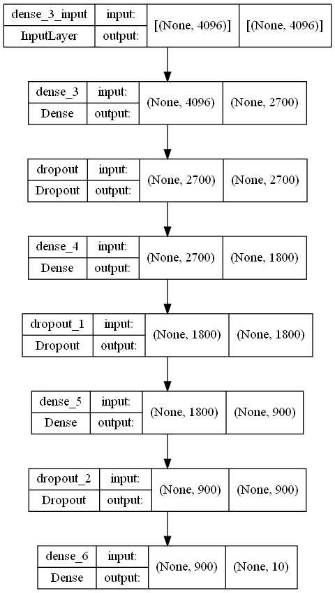

```python
plot_model(model3, show_shapes=True, show_layer_names=True)
```

```python
train_model(model3,
            (X_train, y_train),
            (X_test, y_test), num_classes)
```

```
x_train shape: (13500, 4096)
13500 train samples
13500 test samples
Test score: 1.9763363599777222
Test accuracy: 0.28422221541404724
```

### S5:

- Take the original RGB images and do not vectorize them. Use these images as the data input for the following models (M.4 and M.5).
- Implement a fourth CNN model (M.4) that includes the following layers: Conv2D, MaxPooling2D, Dropout, Flatten, Dense.

Q5.1: Calculate classification accuracy on the test data.

Answer: 53.94074320793152%

Q5.2: Compare against previous models. Which model was the "best"? Why?

Model 4 is the best because it contains CNN, which detects the features of the image accurately.

```python
RGB_eurosat=[]
for img in files:
  img_arr = imread(img)
  RGB_eurosat.append(img_arr)
```

```python
RGB_eurosat1=np.vstack(RGB_eurosat).reshape(27000,64,64,3)
RGB_eurosat1.shape
```

```
(27000, 64, 64, 3)
```

```python
eurosat_label2.shape
```

```
(27000,)
```

```python
#Split the data into training (50%) and testing sets (50%)
#stratified on class labels (equal percentage of each class type in train and test sets)
X_train, X_test, y_train, y_test = train_test_split(RGB_eurosat1, eurosat_label2, stratify = eurosat_label2, train_size = 0.5, random_state= 10)
```

```python
X_train.shape
```

```
(13500, 64, 64, 3)
```

```python
#M4: CNN that includes the following layers: Conv2D, MaxPooling2D, Dropout, Flatten, Dense

# number of convolutional filters to use
filters = 32
# convolution kernel size
kernel_size = 3
# size of pooling area for max pooling
pool_size = 2

input_shape=(64,64,3)
feature_layers = [
    Conv2D(filters, kernel_size,
           padding='valid',
           input_shape=input_shape),
    MaxPooling2D(pool_size=pool_size),
    Dropout(0.25),
    Flatten(),
    Dense(num_classes, activation='softmax')
]
```

```python
# create complete model
model4 = Sequential(feature_layers)
model4.summary()
```

```
Model: "sequential_3"
_________________________________________________________________
 Layer (type)                Output Shape              Param #
=================================================================
 conv2d (Conv2D)             (None, 62, 62, 32)        896

 max_pooling2d (MaxPooling2D  (None, 31, 31, 32)       0
 )

 dropout_3 (Dropout)         (None, 31, 31, 32)        0

 flatten (Flatten)           (None, 30752)             0

 dense_7 (Dense)             (None, 10)                307530

=================================================================
Total params: 308,426
Trainable params: 308,426
Non-trainable params: 0
_________________________________________________________________
```

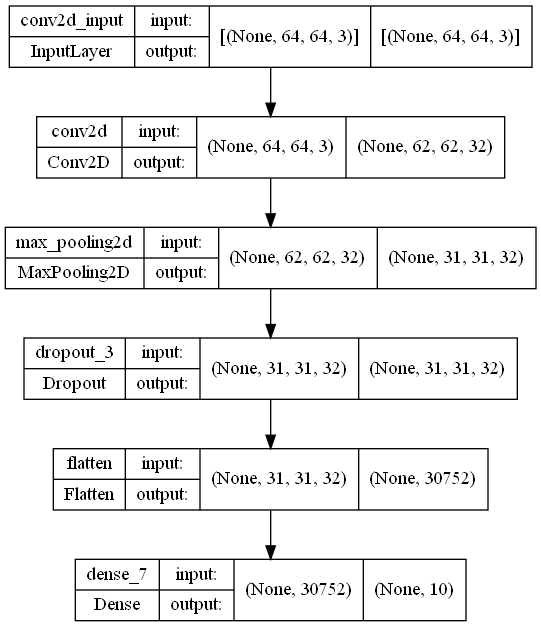

```python
plot_model(model4, show_shapes=True, show_layer_names=True)
```

```python
train_model(model4,
            (X_train, y_train),
            (X_test, y_test), num_classes)
```

```
x_train shape: (13500, 64, 64, 3)
13500 train samples
13500 test samples
Test score: 1.2394036054611206
Test accuracy: 0.5394074320793152
```

### S6:

- Using RGB images from S5, implement a fifth deep learning model (M.5) targeting accuracy that will outperform all previous models. You are free to use any tools and techniques, as well as pre-trained models for transfer learning.

Q6.1: Describe the model you built, and why you chose it.

I applied a CNN model that contains the Conv2D, MaxPooling2D, Dropout, Flatten, Dense because CNN captures the image feature well. I also tried adding more layers but the accuracy rate does not improve.

Q6.2: Calculate classification accuracy on the test data.

67.637038230896%

Q6.3: Compare against previous models. Which model was the "best"? Why?

Model5 is the best as the accuracy rate enhanced a lot.

```python
feature_layers1 = [
    Conv2D(256, kernel_size=(3, 3),
                 activation='relu',
                 input_shape=input_shape,
                 data_format='channels_last', padding = "same"),
    MaxPooling2D(pool_size=(3, 3), padding = "same"),
    Dropout(0.25),
    Flatten(),
    Dense(num_classes, activation='softmax')
]

# create complete model
model5 = Sequential(feature_layers1)

train_model(model5,
            (X_train, y_train),
            (X_test, y_test), num_classes)
```

```
x_train shape: (13500, 64, 64, 3)
13500 train samples
13500 test samples
Test score: 0.9595135450363159
Test accuracy: 0.67637038230896
```

```python
model5.summary()
```

```
Model: "sequential_4"
_________________________________________________________________
 Layer (type)                Output Shape              Param #
=================================================================
 conv2d_1 (Conv2D)           (None, 64, 64, 256)       7168

 max_pooling2d_1 (MaxPooling  (None, 22, 22, 256)      0
 2D)

 dropout_4 (Dropout)         (None, 22, 22, 256)       0

 flatten_1 (Flatten)         (None, 123904)            0

 dense_8 (Dense)             (None, 10)                1239050

=================================================================
Total params: 1,246,218
Trainable params: 1,246,218
Non-trainable params: 0
_________________________________________________________________
```

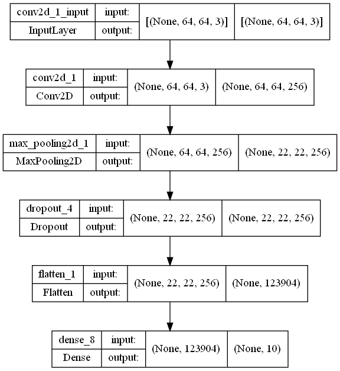

```python
plot_model(model5, show_shapes=True, show_layer_names=True)
```

```python
# What are the two classes with the highest labeling error? Explain using data and showing mis-classified examples.
results = model5.predict(X_test)
results
```

```
array([[0., 0., 0., ..., 0., 0., 0.],
       [0., 0., 0., ..., 0., 0., 0.],
       [0., 0., 0., ..., 0., 0., 0.],
       ...,
       [0., 0., 0., ..., 0., 0., 0.],
       [0., 0., 0., ..., 0., 0., 0.],
       [0., 0., 0., ..., 0., 0., 0.]], dtype=float32)
```

```python
y_pred = np.argmax(results,axis=1)
```

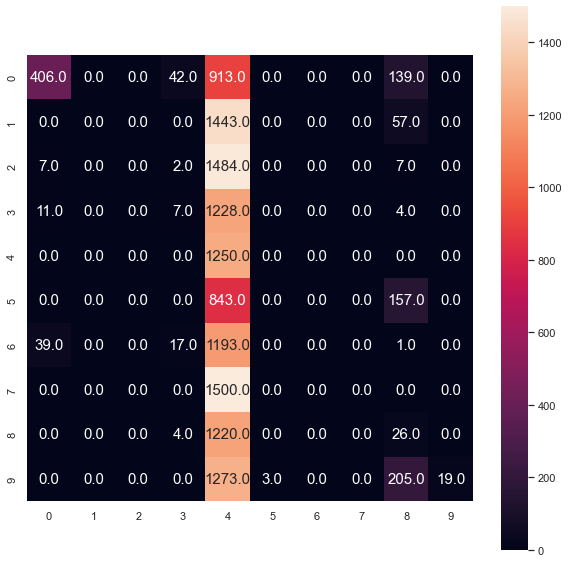

```python
import seaborn as sn
import pandas as pd
import matplotlib.pyplot as plt

array = confusion_matrix(y_test, y_pred)

df_cm = pd.DataFrame(array, range(10), range(10))

plt.figure(figsize=(10,10))
sn.set(font_scale=1) # for label size
sn.heatmap(df_cm, annot=True, annot_kws={"size": 15}, cbar=True, square= True, fmt='.1f') # font size

plt.show()
```

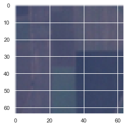

```python
#example: successfully predict as label 3
test3 = np.where((y_test== 3) & (y_pred == 3))[0][0]
tmpimg3 = imread(files[test3])
imshow(tmpimg3)
show()
```

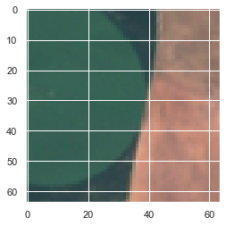

```python
#showing mis-classified examples
#mislabel 3 as 4
test34 = np.where((y_test== 3) & (y_pred == 4))[0][0]
test34_img = imread(files[test34])
imshow(test34_img)
show()
```

### S7:

- Apply your best model on multispectral images. You may use whichever image channels you wish, so long as you use more than just RGB (although you are not required to use any color channels).

Q7.1: Calculate classification accuracy on the test data.

Q7.2: Compare against results using RGB images.

The accuracy rate using four bands from multispectral images is 63.59259486198425%, which is slightly lower than using RGB image (67.637038230896%).

```python
#read multispectral images
files1=[]
filedir1=r"EuroSATallBands/ds/images/remote_sensing/otherDatasets/sentinel_2/tif"
for file in glob.glob(filedir1 + os.sep + "*" + os.sep + "*.tif"):
  files1.append(file)
```

```python
img = tifffile.imread(files1[0])
img.shape
```

```
(64, 64, 13)
```

```python
#apply to the whole dataset
mutli_eurosat=[]
for img in files1:
  img_arr = tifffile.imread(img)
  mutli_eurosat.append(img_arr)
```

```python
#change list of arrays into matrix
mutli_eurosat1=np.vstack(mutli_eurosat).reshape(27000,64,64,13)
mutli_eurosat1.shape
```

```
(27000, 64, 64, 13)
```

```python
#just read four bands
mutli_eurosat2=mutli_eurosat1[:,:,:,:4]
mutli_eurosat2.shape
```

```
(27000, 64, 64, 4)
```

```python
#Split the data into training (50%) and testing sets (50%)
#stratified on class labels (equal percentage of each class type in train and test sets)
X_train, X_test, y_train, y_test = train_test_split(mutli_eurosat2, eurosat_label2, stratify = eurosat_label2, train_size = 0.5, random_state= 10)
```

```python
input_shape=(64,64,4)
feature_layers1 = [
         Conv2D(256, kernel_size=(3, 3),
                 activation='relu',
                 input_shape=input_shape,
                 data_format='channels_last', padding = "same"),
    MaxPooling2D(pool_size=(3, 3), padding = "same"),
    Dropout(0.25),
    Flatten(),
    Dense(num_classes, activation='softmax')
]

# create complete model
model6 = Sequential(feature_layers1)

train_model(model6,
            (X_train, y_train),
            (X_test, y_test), num_classes)
```

```
x_train shape: (13500, 64, 64, 4)
13500 train samples
13500 test samples
Test score: 1.0128611326217651
Test accuracy: 0.6359259486198425
```